# Final project

Borbala Varga

2024-12-15

## Research questions

The aim of this research is to evaluate the presence of women in the field of astronauts, focusing on questions: 1. are they better represented in later years 2. what rank do they obtain 3. what differences can be seen among nations in this regard

The data was part of TidyTuesday (2020-07-14), original data: https://github.com/rfordatascience/tidytuesday/blob/main/data/2020/2020-07-14/astronauts.csv

```r
#Loading & initial cleaning of the data set, the unknown values has been already handled by the uploader of the data set as was reported on the TidyTuesday page


astronauts <- read_csv("https://github.com/rfordatascience/tidytuesday/raw/refs/heads/main/data/2020/2020-07-14/astronauts.csv") %>%
  clean_names()
glimpse(astronauts)
```

```
## Rows: 1,277
## Columns: 24
## $ id                       <dbl> 1, 2, 3, 4, 5, 6, 7, 8, 9, 10, 11, 12, 13, 14…
## $ number                   <dbl> 1, 2, 3, 3, 4, 5, 5, 6, 6, 7, 7, 7, 8, 8, 9, …
## $ nationwide_number        <dbl> 1, 2, 1, 1, 2, 2, 2, 4, 4, 3, 3, 3, 4, 4, 5, …
## $ name                     <chr> "Gagarin, Yuri", "Titov, Gherman", "Glenn, Jo…
## $ original_name            <chr> "ГАГАРИН Юрий Алексеевич", "ТИТОВ Герман Степ…
## $ sex                      <chr> "male", "male", "male", "male", "male", "male…
## $ year_of_birth            <dbl> 1934, 1935, 1921, 1921, 1925, 1929, 1929, 193…
## $ nationality              <chr> "U.S.S.R/Russia", "U.S.S.R/Russia", "U.S.", "…
## $ military_civilian        <chr> "military", "military", "military", "military…
## $ selection                <chr> "TsPK-1", "TsPK-1", "NASA Astronaut Group 1",…
## $ year_of_selection        <dbl> 1960, 1960, 1959, 1959, 1959, 1960, 1960, 196…
## $ mission_number           <dbl> 1, 1, 1, 2, 1, 1, 2, 1, 2, 1, 2, 3, 1, 2, 1, …
## $ total_number_of_missions <dbl> 1, 1, 2, 2, 1, 2, 2, 2, 2, 3, 3, 3, 2, 2, 3, …
## $ occupation               <chr> "pilot", "pilot", "pilot", "PSP", "Pilot", "p…
## $ year_of_mission          <dbl> 1961, 1961, 1962, 1998, 1962, 1962, 1970, 196…
## $ mission_title            <chr> "Vostok 1", "Vostok 2", "MA-6", "STS-95", "Me…
## $ ascend_shuttle           <chr> "Vostok 1", "Vostok 2", "MA-6", "STS-95", "Me…
## $ in_orbit                 <chr> "Vostok 2", "Vostok 2", "MA-6", "STS-95", "Me…
## $ descend_shuttle          <chr> "Vostok 3", "Vostok 2", "MA-6", "STS-95", "Me…
## $ hours_mission            <dbl> 1.77, 25.00, 5.00, 213.00, 5.00, 94.00, 424.0…
## $ total_hrs_sum            <dbl> 1.77, 25.30, 218.00, 218.00, 5.00, 519.33, 51…
## $ field21                  <dbl> 0, 0, 0, 0, 0, 0, 0, 0, 0, 0, 0, 0, 0, 0, 0, …
## $ eva_hrs_mission          <dbl> 0.00, 0.00, 0.00, 0.00, 0.00, 0.00, 0.00, 0.0…
## $ total_eva_hrs            <dbl> 0.00, 0.00, 0.00, 0.00, 0.00, 0.00, 0.00, 0.0…
```

```r
cat("The data set starts with the first human in space, Yuri Gagarin in", min(astronauts$year_of_mission), "and ends in", max(astronauts$year_of_mission), "which time frame contains", max(astronauts$number), "person who has been in space, in total", max(astronauts$id), "number of space travels.")
```

```
## The data set starts with the first human in space, Yuri Gagarin in 1961 and ends in 2019 which time frame contains 565 person who has been in space, in total 1277 number of space travels.
```

## Exploratory data analysis

### Preparing data

Searching and eliminating coding errors are necessary for variables which are relevant for the research, ‘occupation’ needed a revision.

```r
# Creating a table where every astronaut is represented only once

astronauts_by_ppl <- astronauts %>%
  group_by(name) %>%
  slice(1)


# Checking the variables we are mostly interested in:
# 1. Occupation

table(astronauts_by_ppl$occupation)
```

```
##
##               commander         flight engineer         Flight engineer
##                      59                      95                       3
##                     MSP      Other (Journalist)   Other (space tourist)
##                     211                       1                       4
##   Other (Space tourist)                   pilot                   Pilot
##                       3                     136                       1
##                     PSP           Space tourist spaceflight participant
##                      48                       2                       1
```

```r
# Cleaning 'occupation' for coding errors

astronauts_by_ppl_corr <- astronauts_by_ppl %>%

  mutate(occupation = case_when(
    occupation == "Flight engineer" ~ "flight engineer",
    occupation == "Other (Journalist)" ~ "journalist",
    occupation == "Other (Space tourist)" ~ "space tourist",
    occupation == "Other (space tourist)" ~ "space tourist",
    occupation == "Space tourist" ~ "space tourist",
    occupation == "Pilot" ~ "pilot",
    TRUE ~ occupation
  ))

table(astronauts_by_ppl_corr$occupation)
```

```
##
##               commander         flight engineer              journalist
##                      59                      98                       1
##                     MSP                   pilot                     PSP
##                     211                     137                      48
##           space tourist spaceflight participant
##                       9                       1
```

```r
# 2. Organisations of the space expeditions ('selection')

head(table(astronauts_by_ppl$selection))
```

```
##
## 1958 USAF Man in Space Soonest, 1960 USAF Dyna-Soar, NASA- 2
##                                                            1
##                                            1959 NASA group 1
##                                                            3
##                                            1962 NASA group 2
##                                                            2
##                                            1963 NASA group 2
##                                                            1
##                                            1963 NASA group 3
##                                                            3
##                                        1965 USAF MOL group 1
##                                                            1
```

```r
tail(table(astronauts_by_ppl$selection))
```

```
##
##                    USAF group USAF MOL Group 2 \r\n NASA- 7
##                             1                             1
##                     Voskhod-1          Voskhod-1 / TsKBEM-1
##                             1                             1
##            Voskhod-1 / TsPK-3                     VVS Women
##                             1                             1
```

```r
# The 'selection' column has been organised according to the location of the organisation, external information sources (e.g. Wikipedia) have been used to decide not evident cases

astronauts_by_ppl_corr <- astronauts_by_ppl_corr %>%

  mutate(selection = ifelse(str_detect(selection, "NASA"), "U.S.", selection)) %>%
  mutate(selection = ifelse(str_detect(selection, "Teacher"), "U.S.", selection)) %>%
  mutate(selection = ifelse(str_detect(selection, "NASA"), "U.S.", selection)) %>%
  mutate(selection = ifelse(str_detect(selection, "States"), "U.S.", selection)) %>%
    mutate(selection = ifelse(str_detect(selection, "Juno"), "U.S.", selection)) %>%
  mutate(selection = ifelse(str_detect(selection, "ATLAS"), "U.S.", selection)) %>%
  mutate(selection = ifelse(str_detect(selection, "PS"), "U.S.", selection)) %>%
  mutate(selection = ifelse(str_detect(selection, "Congress"), "U.S.", selection))%>%
    mutate(selection = ifelse(str_detect(selection, "Spacelab"), "U.S.", selection))%>%
  mutate(selection = ifelse(str_detect(selection, "Terra"), "U.S.", selection)) %>%
    mutate(selection = ifelse(str_detect(selection, "USAF"), "U.S.", selection)) %>%
    mutate(selection = ifelse(str_detect(selection, "TsPK"), "U.S.S.R./Russia", selection)) %>%
  mutate(selection = ifelse(str_detect(selection, "VVS"), "U.S.S.R./Russia", selection)) %>%
    mutate(selection = ifelse(str_detect(selection, "LII"), "U.S.S.R./Russia", selection)) %>%
    mutate(selection = ifelse(str_detect(selection, "Voskhod"), "U.S.S.R./Russia", selection)) %>%
    mutate(selection = ifelse(str_detect(selection, "NPOE"), "U.S.S.R./Russia", selection)) %>%
    mutate(selection = ifelse(str_detect(selection, "osmos"), "U.S.S.R./Russia", selection)) %>%
    mutate(selection = ifelse(str_detect(selection, "IMBP"), "U.S.S.R./Russia", selection)) %>%
    mutate(selection = ifelse(str_detect(selection, "USSR"), "U.S.S.R./Russia", selection)) %>%
    mutate(selection = ifelse(str_detect(selection, "RKKE"), "U.S.S.R./Russia", selection)) %>%
    mutate(selection = ifelse(str_detect(selection, "AMN"), "U.S.S.R./Russia", selection)) %>%
    mutate(selection = ifelse(str_detect(selection, "TsKBEM"), "U.S.S.R./Russia", selection)) %>%
   mutate(selection = ifelse(str_detect(selection, "MKS"), "U.S.S.R./Russia", selection)) %>%
   mutate(selection = ifelse(str_detect(selection, "MAP"), "U.S.S.R./Russia", selection)) %>%
   mutate(selection = ifelse(str_detect(selection, "Politician"), "U.S.S.R./Russia", selection)) %>%
   mutate(selection = ifelse(str_detect(selection, "Kazak"), "Kazakhstan", selection)) %>%
  mutate(selection = ifelse(str_detect(selection, "Kzazkh"), "Kazakhstan", selection)) %>%
    mutate(selection = ifelse(str_detect(selection, "NASDA"), "Japan", selection)) %>%
  mutate(selection = ifelse(str_detect(selection, "TBS"), "Japan", selection)) %>%
     mutate(selection = ifelse(str_detect(selection, "JAXA"), "Japan", selection)) %>%
    mutate(selection = ifelse(str_detect(selection, "EAC"), "E.U.", selection)) %>%
    mutate(selection = ifelse(str_detect(selection, "ESA"), "E.U.", selection)) %>%
    mutate(selection = ifelse(str_detect(selection, "China"), "China", selection)) %>%
    mutate(selection = ifelse(str_detect(selection, "CNES"), "France", selection)) %>%
    mutate(selection = ifelse(str_detect(selection, "CSA"), "Canada", selection)) %>%
     mutate(selection = ifelse(str_detect(selection, "NRC"), "Canada", selection)) %>%
    mutate(selection = ifelse(str_detect(selection, "DLR"), "Germany", selection)) %>%
    mutate(selection = ifelse(str_detect(selection, "Tourist"), "Tourists", selection)) %>%
    mutate(selection = ifelse(str_detect(selection, "Mir"), "Tourists", selection)) %>%
    mutate(selection = ifelse(str_detect(selection, "N/A"), "Tourists", selection)) %>%
    mutate(selection = ifelse(str_detect(selection, "MBRSC"), "UAE", selection)) %>%
    mutate(selection = ifelse(str_detect(selection, "Angkasawan"), "Malaysia", selection))

table(astronauts_by_ppl_corr$selection)
```

```
##
##     Afghanistan         Austria          Canada           China            E.U.
##               1               1               9              11              28
##          France         Germany           Japan      Kazakhstan        Malaysia
##               3               3              12               3               1
##    Saudi-Arabia        Slovakia     South Korea           Syria        Tourists
##               1               1               1               1               6
##            U.S. U.S.S.R./Russia             UAE
##             349             131               1
```

```r
# 3. Nationality

table(astronauts_by_ppl_corr$nationality)
```

```
##
##              Afghanistan                Australia                  Austria
##                        1                        1                        1
##                  Belgium                   Brazil                 Bulgaria
##                        2                        1                        1
##                   Canada                    China                     Cuba
##                       10                       11                        1
##           Czechoslovakia                  Denmark                   France
##                        1                        1                       10
##                  Germany                   Hungry                    India
##                       11                        1                        1
##                   Israel                    Italy                    Japan
##                        1                        7                       12
##               Kazakhstan                    Korea                  Malysia
##                        1                        1                        1
##                   Mexico                 Mongolia               Netherland
##                        1                        1                        2
##                   Poland Republic of South Africa                  Romania
##                        1                        1                        1
##             Saudi Arabia                 Slovakia                    Spain
##                        1                        1                        1
##                   Sweden              Switzerland                    Syria
##                        1                        1                        1
##                     U.K.                U.K./U.S.                     U.S.
##                        2                        3                      344
##           U.S.S.R/Russia          U.S.S.R/Ukraine                      UAE
##                      122                        1                        1
##                  Vietnam
##                        1
```

```r
# There are 3 double citizens whose nationality is going to be changed based on their chosen nation (info obtained from Wikipedia)

double_nat <- astronauts_by_ppl_corr %>%
  filter(nationality == "U.K./U.S.") %>%
  select(name)

double_nat
```

```
## # A tibble: 3 × 1
## # Groups:   name [3]
##   name
##   <chr>
## 1 Garriott, Richard Allen
## 2 Patrick, Nicholas J. M.
## 3 Sellers, Piers J.
```

```r
astronauts_by_ppl_corr <- astronauts_by_ppl_corr %>%
  mutate(nationality = if_else(nationality == "U.K./U.S.", "U.S.", nationality))

# Two countries' name are misspelled

astronauts_by_ppl_corr <- astronauts_by_ppl_corr %>%
  mutate(nationality = if_else(nationality == "Hungry", "Hungary", nationality)) %>%
  mutate(nationality = if_else(nationality == "Malysia", "Malaysia", nationality))
```

### Discovering trends using plots

Number of women present per year -

```r
# Subgroups for seeing trends between male vs. female astronauts

table(astronauts_by_ppl$sex) # there is no coding error
```

```
##
## female   male
##     64    500
```

```r
astronauts_woman <- astronauts_by_ppl_corr %>%
  filter(sex == "female")

astronauts_man <- astronauts_by_ppl_corr %>%
  filter(sex == "male")


# First woman in space

first_woman <- astronauts_woman %>% filter(year_of_selection == min(astronauts_woman$year_of_selection)) %>% select(name)

first_woman_date <- astronauts_woman %>% filter(name == first_woman) %>% ungroup() %>% select(year_of_selection)
```

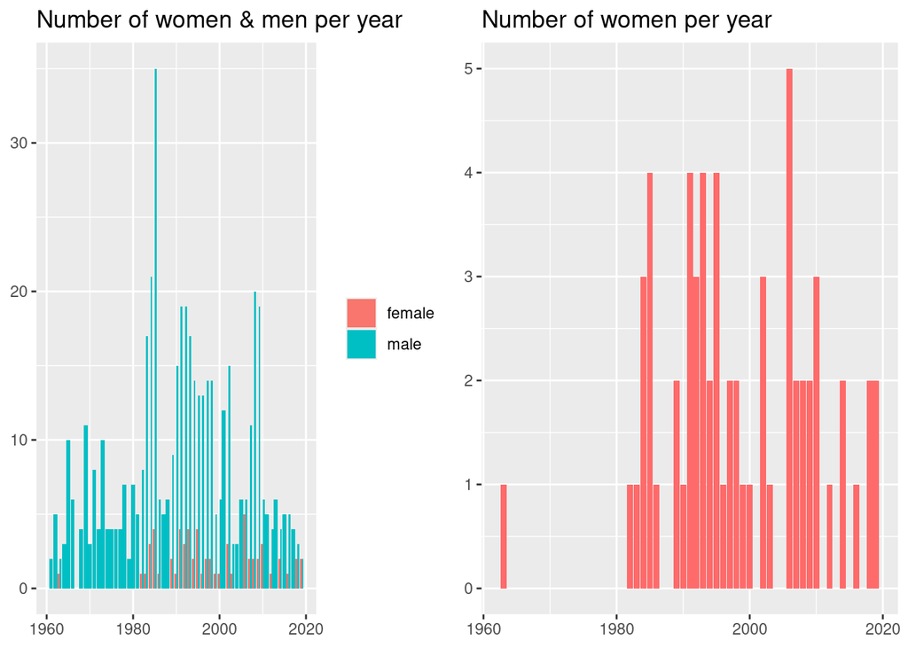

```r
# Plots

plot_sex_year <- ggplot(astronauts_by_ppl_corr, aes(x = year_of_mission, fill = sex)) +
  geom_bar(position = "dodge") +
  labs(title = "Number of women & men per year") +
  theme(axis.title.x = element_blank(), axis.title.y = element_blank(), legend.title = element_blank())

plot_women_year <- ggplot(astronauts_woman, aes(x = year_of_mission)) +
  geom_bar(fill = "indianred1") +
  labs(title = "Number of women per year") +
  theme(axis.title.x = element_blank(), axis.title.y = element_blank(), legend.title = element_blank())

grid.arrange(plot_sex_year, plot_women_year, ncol = 2)
```

```r
cat("There have been", sum(astronauts_by_ppl$sex == "female"), "women, and", sum(astronauts_by_ppl$sex == "male"), "men astronauts, both professional and tourists.")
```

```
## There have been 64 women, and 500 men astronauts, both professional and tourists.
```

```r
cat("In the plots above it is visible, that except from the first woman in space,", as.character(first_woman), "in", as.character(first_woman_date), "women have been represented in the field from ~1980, but still fairly unevenly, and there is no visible trend in terms of  women being more represented with time.")
```

[output not shown]

Differences between men & women in occupation and total numbers of hours spent in space -

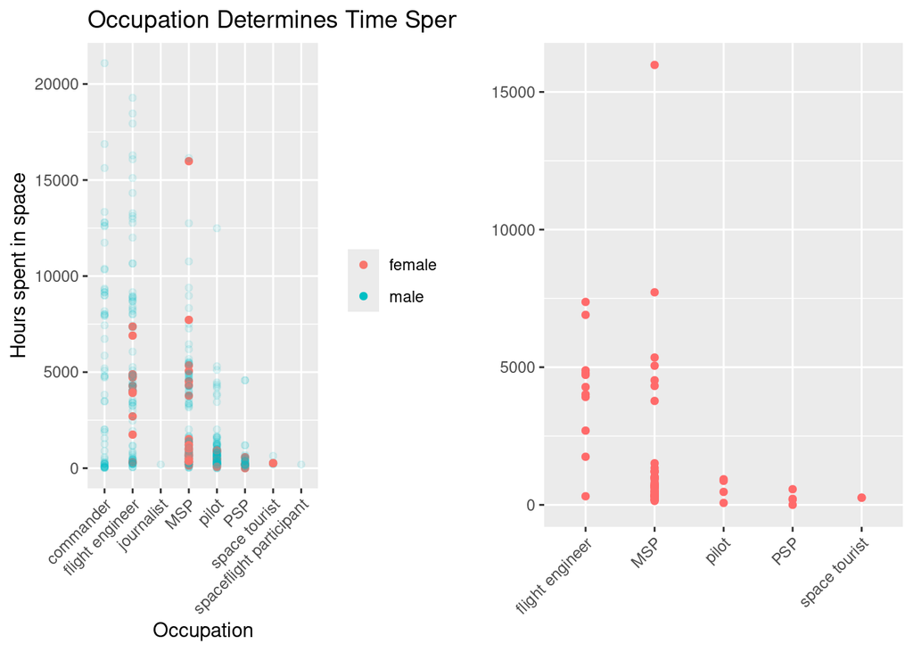

```r
plot_men_occ <- ggplot(astronauts_by_ppl_corr, aes(x = occupation, y = total_hrs_sum, color = sex, alpha = ifelse(sex == "male", 0, 1))) +
  geom_point() +
  labs(title = "Occupation Determines Time Spent in Space",
       x = "Occupation",
       y = "Hours spent in space",
       color = "") +
  theme(axis.text.x = element_text(angle = 45, hjust = 1)) +
  guides(alpha = FALSE)
plot_women_occ <- ggplot(astronauts_woman, aes(x = occupation, y = total_hrs_sum)) +
  geom_point(color = "indianred1") +
  labs(title = "",
       x = "",
       y = "") +
  theme(axis.text.x = element_text(angle = 45, hjust = 1))

grid.arrange(plot_men_occ, plot_women_occ, ncol = 2)
```

```r
cat("There is no woman commander, nor journalist, the distribution of the rest of the occupations seems similarly distributed to men's occupation.\nHours spent in space seems much less than men's data.")
```

```
## There is no woman commander, nor journalist, the distribution of the rest of the occupations seems similarly distributed to men's occupation.
## Hours spent in space seems much less than men's data.
```

Numbers of nationalities represented in space -

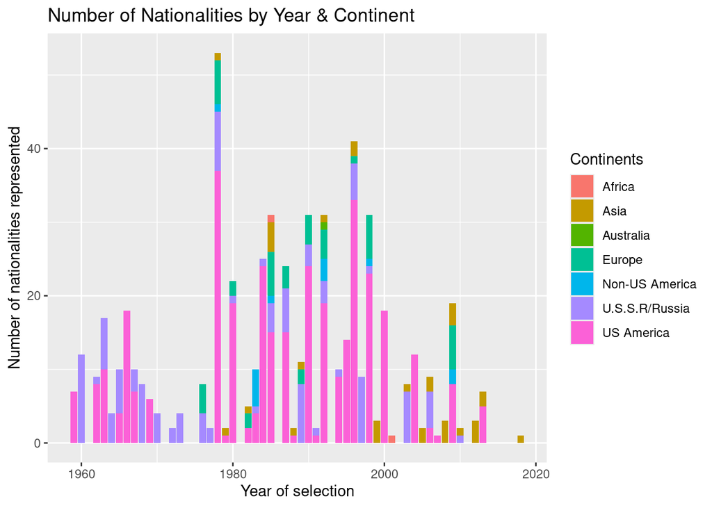

```r
# Nationalities grouped by continents

astronauts_by_ppl_corr <- astronauts_by_ppl_corr %>%
  mutate(continent = case_when(
    nationality %in% c("France", "Germany", "Italy", "U.K.", "Russia", "Austria", "Denmark", "Czechoslovakia", "Bulgaria", "Belgium", "Spain", "Romania", "Slovakia", "Netherland", "Sweden", "Switzerland", "U.S.S.R/Ukraine", "Hungary", "Poland") ~ "Europe",
    nationality %in% c("Cuba", "Mexico", "Brazil", "Canada") ~ "Non-US America",
    nationality %in% c("U.S.") ~ "US America",
    nationality %in% c("China", "Japan", "India", "Korea", "Vietnam", "Syria", "Mongolia", "Malaysia", "Korea", "Israel", "UAE", "Afghanistan", "Kazakhstan") ~ "Asia",
    nationality %in% c("Republic of South Africa", "Saudi Arabia") ~ "Africa",
    nationality %in% c("Australia") ~ "Australia",
    nationality %in% c("U.S.S.R/Russia") ~ "U.S.S.R/Russia",
    TRUE ~ "Other"
  ))


# Plots

nationalities_per_year <- astronauts_by_ppl_corr %>%
  count(year_of_selection, continent)

ggplot(nationalities_per_year, aes(x = year_of_selection, y = n, fill = continent)) +
  geom_histogram(stat = "identity", position = "stack") +
  labs(
    title = "Number of Nationalities by Year & Continent",
    x = "Year of selection",
    y = "Number of nationalities represented",
    fill = "Continents")
```

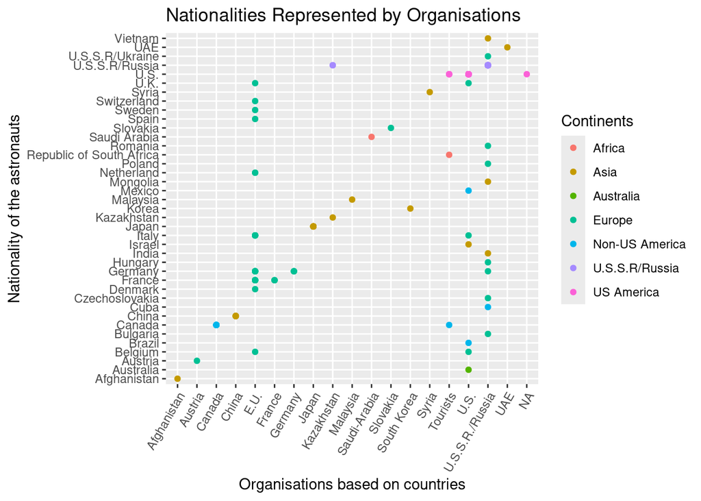

```r
ggplot(astronauts_by_ppl_corr, aes(x = selection, y = nationality, color = continent)) +
  geom_point() +
  labs(title = "Nationalities Represented by Organisations",
       x = "Organisations based on countries",
       y = "Nationality of the astronauts",
       color = "Continents") +
    theme(axis.text.x = element_text(angle = 60, hjust = 1))
```

```r
cat("The trend for different nationalities being represented seems similar for the previous data on women, both starting around 1980. With the decline of interest in space travels around 2000 these trends seem to fade as well.\nEU and the majority of the nations represent their own people in space. Exceptions are US and USSR/Russia, who gave opportunities to participants from more countries, supposedly as for USSR/Russia these are based mostly on past soviet connections.")
```

```
## The trend for different nationalities being represented seems similar for the previous data on women, both starting around 1980. With the decline of interest in space travels around 2000 these trends seem to fade as well.
## EU and the majority of the nations represent their own people in space. Exceptions are US and USSR/Russia, who gave opportunities to participants from more countries, supposedly as for USSR/Russia these are based mostly on past soviet connections.
```

## Data analysis

### Building the model

Based on the explanatory data analysis a question arose: is there a connection between women being present in the field of astronauts and men and also different nations being present?

```r
# Creating a table for the necessary data:

summary_data <- astronauts_by_ppl_corr %>%
  group_by(year_of_selection, nationality, sex) %>%
  summarise(count = n()) %>%
  pivot_wider(names_from = sex, values_from = count, values_fill = list(count = 0))
nationality_nr <- summary_data %>%
  group_by(year_of_selection) %>%
  summarise(nationality_nr = n_distinct(nationality))

merged_data <- summary_data %>%
  left_join(nationality_nr, by = "year_of_selection")

merged_data
```

```
## # A tibble: 122 × 5
## # Groups:   year_of_selection, nationality [122]
##    year_of_selection nationality     male female nationality_nr
##                <dbl> <chr>          <int>  <int>          <int>
##  1              1959 U.S.               7      0              1
##  2              1960 U.S.S.R/Russia    12      0              1
##  3              1962 U.S.               8      0              2
##  4              1962 U.S.S.R/Russia     0      1              2
##  5              1963 U.S.              10      0              2
##  6              1963 U.S.S.R/Russia     7      0              2
##  7              1964 U.S.S.R/Russia     4      0              1
##  8              1965 U.S.               4      0              2
##  9              1965 U.S.S.R/Russia     6      0              2
## 10              1966 U.S.              18      0              1
## # ℹ 112 more rows
```

```r
# and a multiple linear regression model:

model <- lm(female ~ male + nationality_nr, data = merged_data)
```

### Influential outliers

Using Cook’s Distance Test it is obvious, that all the points are below 1, thus there are no influential outliers.

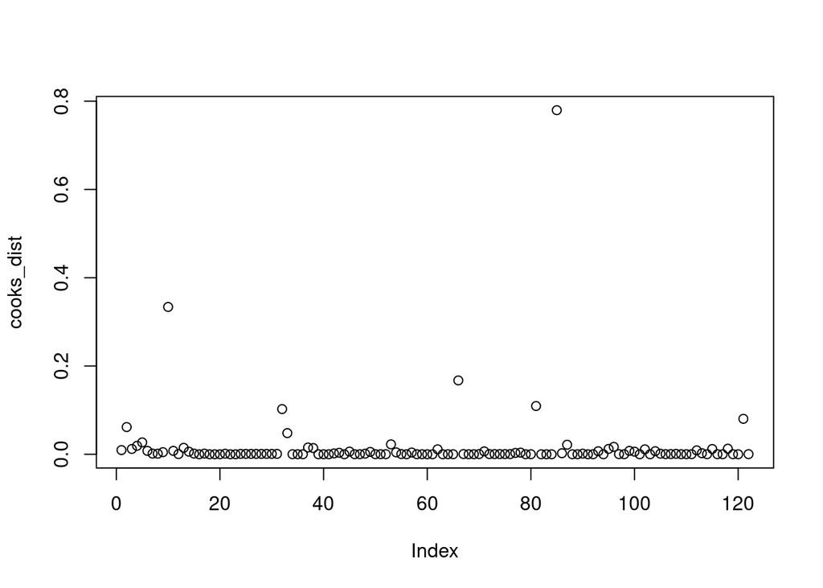

```r
cooks_dist <- cooks.distance(model)

plot(cooks_dist)
```

```r
cooks.distance(model)[which.max(cooks.distance(model))]
```

```
##        85
## 0.7795641
```

### Assumptions

Normality. Shapiro-Wilk normality test shows that the data is not normally distributed (p < 0.001), which means that a transformation of the data is necessary.

```r
residuals <- rstandard(model)

shapiro.test(residuals)
```

```
##
##  Shapiro-Wilk normality test
##
## data:  residuals
## W = 0.86856, p-value = 5.279e-09
```

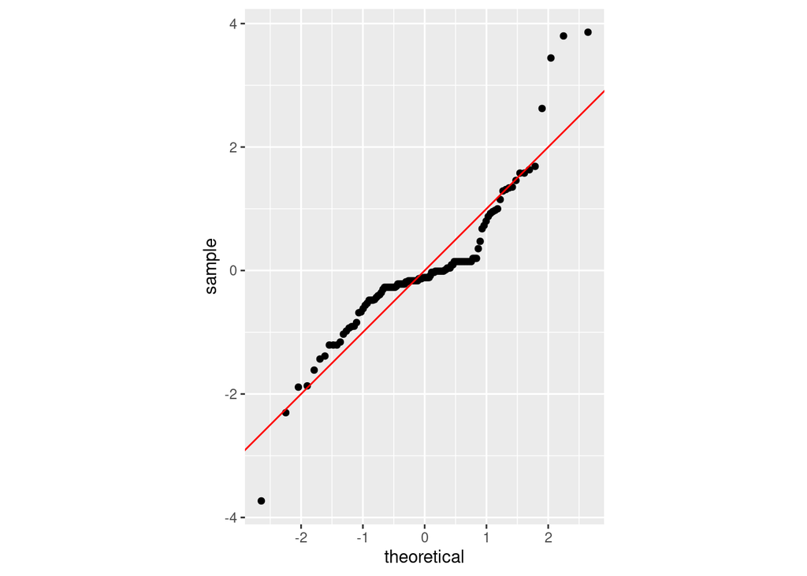

```r
ggplot() +
  geom_qq(aes(sample = residuals)) +
  geom_abline(color = "red") +
  coord_fixed()
```

Correcting for non-normal distribution - with log transformation. The results show that this transformation was not enough for correcting for non-normality, and the results should be handled with caution!

```r
female_log  <- log(merged_data$female + 1)

model_log <- lm(female_log ~ male + nationality_nr, data = merged_data)

residuals_log <- residuals(model_log)

shapiro.test(residuals_log)
```

```
##
##  Shapiro-Wilk normality test
##
## data:  residuals_log
## W = 0.87394, p-value = 9.133e-09
```

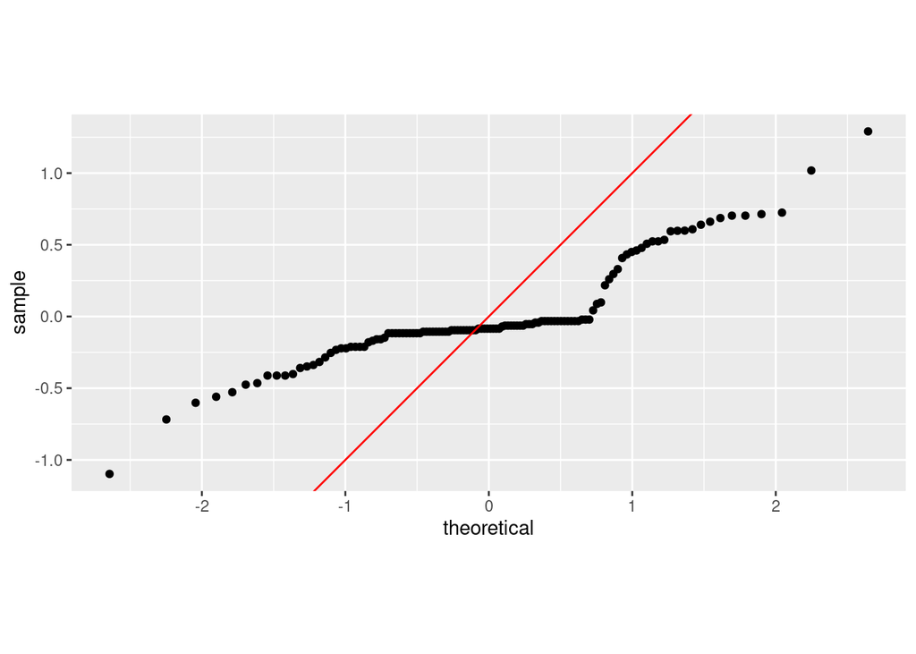

```r
ggplot() +
  geom_qq(aes(sample = residuals_log)) +
  geom_abline(color = "red") +
  coord_fixed()
```

Linearity. Linearity assumption is slightly violated where the numbers of ‘male’ is low.

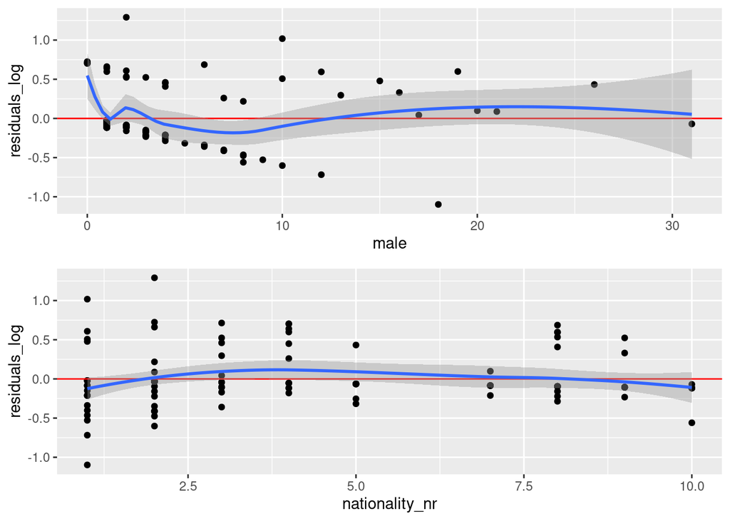

```r
residuals_fitted <- merged_data %>%
  ungroup()%>%
  mutate(fitted = fitted(model_log))

linearity_male <- ggplot(residuals_fitted, aes(male, residuals_log)) +
  geom_point() +
  geom_hline(yintercept = 0, color = "red") +
  geom_smooth()

linearity_nat <- ggplot(residuals_fitted, aes(nationality_nr, residuals_log)) +
  geom_point() +
  geom_hline(yintercept = 0, color = "red") +
  geom_smooth()

grid.arrange(linearity_male, linearity_nat, nrow = 2)
```

Homogeneity of variance. Sine the Breusch-Pagan Test resulted with a p ~ 0.001, heteroscedasticity is evident in the model, even when log transformed. This means, that the variance of the residuals are not constant, and further steps needed to be taken.

```r
ncvTest(model_log)
```

```
## Non-constant Variance Score Test
## Variance formula: ~ fitted.values
## Chisquare = 9.828758, Df = 1, p = 0.001718
```

Multicolinearity assumption. Since all the results are below 3, there is no multicolinearity present in the model.

```r
vif(model_log)
```

```
##           male nationality_nr
##       1.010646       1.010646
```

### Results

The results show significant connection between women and men being present in the field, but not the variability of nations being present.

```r
summary(model)
```

```
##
## Call:
## lm(formula = female ~ male + nationality_nr, data = merged_data)
##
## Residuals:
##      Min       1Q   Median       3Q      Max
## -2.76612 -0.22597 -0.08675  0.10996  2.93846
##
## Coefficients:
##                Estimate Std. Error t value Pr(>|t|)
## (Intercept)    -0.36014    0.13988  -2.575   0.0113 *
## male            0.17150    0.01265  13.560   <2e-16 ***
## nationality_nr  0.03934    0.02262   1.739   0.0846 .
## ---
## Signif. codes:  0 '***' 0.001 '**' 0.01 '*' 0.05 '.' 0.1 ' ' 1
##
## Residual standard error: 0.7674 on 119 degrees of freedom
## Multiple R-squared:  0.6073, Adjusted R-squared:  0.6007
## F-statistic:    92 on 2 and 119 DF,  p-value: < 2.2e-16
```

## Conclucion

Since all the assumptions of linear regressions (except for multilinearity) have been violated, even though the results show p<0.001 significant correlation between women and men being present in the field, this result should be handled with caution, and a more robust model would be needed to give a certain result.